# Challenge 1 - Time series

Pierre Chevallier

1/24/2021

# Setup

The setup consists of importing the data, and loading the libraries for the analysis. We will work using this RMarkdown document to include the findings of our research. This is for 2 reasons:

- Making the document easily maintainable with one place for the writing and the coding (especially to include it later on the blog)
- To share it and export it easily so it can be hosted on GitHub with the code and the findings

I attached in quote excerpts from the challenge requirements to make sure to keep track of the end goal.

Also we will use the packages:

- `Dplyr` for easier manipulation, this is a must have for R (maybe I’ll do a topic on that)
- `zoo` for the year month handling
- `ggplot2` for generating charts
- `patchwork` for the layout of the ggplot charts, [reference](https://github.com/thomasp85/patchwork)

```r
knitr::opts_chunk$set(echo = TRUE)
library(dplyr)
library(zoo)
```

```r
library(ggplot2)
library(patchwork)
# Functions ----
source_files <- list.files(path=paste0(params$path,"scripts/"), pattern = ".*R")
for (file in source_files) {
  source(paste0(params$path,"/scripts/", file))
}
# Data ----
dairy_data <- read.csv(paste0(params$path,"Take_home_1/Challenge 1_cadairydata.csv"))
```

> In this challenge, you will create a forecasting model for dairy production. The forecasting model is based on an existing dataset of dairy production history for California.
> - Open Challenge 1_cadairydata.csv file.
> - View the contents of the `cadairydata.csv` file, noting that it contains dairy production data from January 1995 to December 2013

Here we are, the data have been loaded just before, so we can have a quick look at it.

```r
head(dairy_data)
```

```
##   X Year.Month Month.Number Year Month Cotagecheese.Prod Icecream.Prod
## 1 1    1995.01            1 1995   Jan             4.370        51.595
## 2 2    1995.02            2 1995   Feb             3.695        56.086
## 3 3    1995.03            3 1995   Mar             4.538        68.453
## 4 4    1995.04            4 1995   Apr             4.280        65.722
## 5 5    1995.05            5 1995   May             4.470        73.730
## 6 6    1995.06            6 1995  June             4.238        77.994
##   Milk.Prod N.CA.Fat.Price
## 1     2.112         0.9803
## 2     1.932         0.8924
## 3     2.162         0.8924
## 4     2.130         0.8967
## 5     2.227         0.8967
## 6     2.124         0.9160
```

```r
str(dairy_data)
```

```
## 'data.frame':    228 obs. of  9 variables:
##  $ X                : int  1 2 3 4 5 6 7 8 9 10 ...
##  $ Year.Month       : num  1995 1995 1995 1995 1995 ...
##  $ Month.Number     : int  1 2 3 4 5 6 7 8 9 10 ...
##  $ Year             : int  1995 1995 1995 1995 1995 1995 1995 1995 1995 1995 ...
##  $ Month            : chr  "Jan" "Feb" "Mar" "Apr" ...
##  $ Cotagecheese.Prod: num  4.37 3.69 4.54 4.28 4.47 ...
##  $ Icecream.Prod    : num  51.6 56.1 68.5 65.7 73.7 ...
##  $ Milk.Prod        : num  2.11 1.93 2.16 2.13 2.23 ...
##  $ N.CA.Fat.Price   : num  0.98 0.892 0.892 0.897 0.897 ...
```

Right now we can see a few things that are interesting, first of all, the data are already converted into a year-month format (numerical format with the year as the integer and the month as a decimal value). Also there are 4 series of data in our dataset. They are all fine, but not very easy to use when typing code, let’s rename them:

- Cotagecheese.Prod -> CottageCheeseProd (typo for Cottage cheese !)
- Icecream.Prod -> IceCreamProd
- Milk.Prod -> MilkProd
- N.CA.Fat.Price -> FatPrice

```r
dairy_data <- dairy_data %>%
  rename(
    CottageCheeseProd = Cotagecheese.Prod,
    IceCreamProd = Icecream.Prod,
    MilkProd = Milk.Prod,
    FatPrice = N.CA.Fat.Price,
    YearMonth = Year.Month,
    MonthNumber = Month.Number
  ) %>%
  mutate(
    YearMonth = as.yearmon(paste(Year, MonthNumber, "1", sep = "-")),
    Date = as.Date(YearMonth)
  )
```

# 1. Patterns in the data

> Identify any patterns in the data if any

We have overall 4 main variables, which we renamed, to be analysed, we first can look at them individually to look in the plot for:

- Trend
- Seasonality

And then we can check them between each other:

- Are they correlated ?
- Are they not correlated ?

Of course, this will yield further questions which we can solve with statistical tests to check for example for [stationarity](https://en.wikipedia.org/wiki/Stationary_process). But first, let’s plot the data and see how they look throughout time.

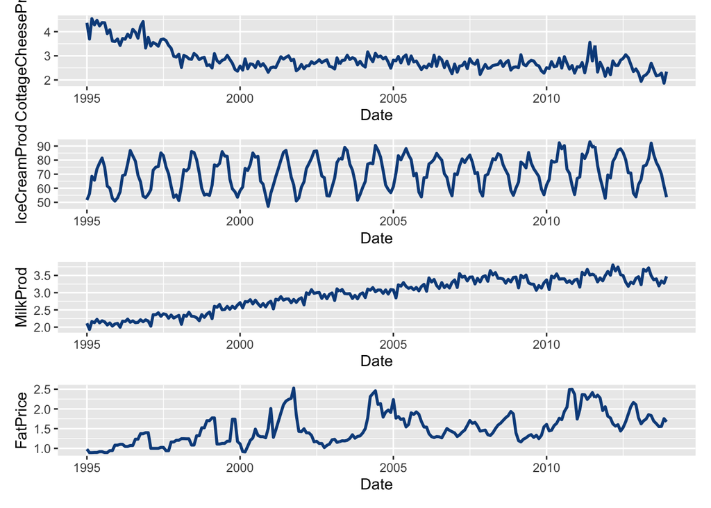

```r
# CotageCheeseProd ----
cot_plot <- buildPlot(dairy_data, x = "Date", y = "CottageCheeseProd")
# IceCreamProd ----
ice_plot <- buildPlot(dairy_data, x = "Date", y = "IceCreamProd")
# IceCreamProd ----
milk_plot <- buildPlot(dairy_data, x = "Date", y = "MilkProd")
# IceCreamProd ----
fat_plot <- buildPlot(dairy_data, x = "Date", y = "FatPrice")

# Displaying the data together
(cot_plot / ice_plot / milk_plot / fat_plot)
```

Ok now that is interesting, let’s sum up what we see from here. I will not dwell on the concepts of trends, seasonality, stationarity and [heteroscedasticity](https://en.wikipedia.org/wiki/Heteroscedasticity). These will maybe be covered in another topic, so let’s sum up what we see for each variables:

| Variable | Property | Compared to other variables |
| --- | --- | --- |
| Cotage cheese production | A trend, and a non-stationary process, but with stochastic component | Could be correlated to milk production |
| Ice Cream Production | A very seasonal product (no wonder, ice cream sales tend to be in summer) | NA |
| Milk Production | A clear trend and maybe a bit of seasonality | Could be correlated to Cottage cheese production |
| Fat Price | An heteroscedastic process with a trend | NA |

# 2. Forecasting the series

> Based on above, create a forecasting model and predict the next 12 months ice cream production and plot the time series using any of the following desired tools (e.g. R, Python, Qlik, PBI, Tableau…)

> | Year | Month | MonthNumber | Ice cream production |
> | --- | --- | --- | --- |
> | 2014 | Jan | 1 |  |
> | 2014 | Feb | 2 |  |
> | 2014 | Mar | 3 |  |
> | 2014 | Apr | 4 |  |
> | 2014 | May | 5 |  |
> | 2014 | Jun | 6 |  |
> | 2014 | Jul | 7 |  |
> | 2014 | Aug | 8 |  |
> | 2014 | Sep | 9 |  |
> | 2014 | Oct | 10 |  |
> | 2014 | Nov | 11 |  |
> | 2014 | Dec | 12 |  |

# 3. Additional insights, findings and accuracy tracking

> Explain to us any additional insights that you discovered and tell us how would you track accuracy forward looking?